# Tidydata y manipulación de datos

Clase N°5

5 de Septiembre

## 0. Objetivo de la clase

Profundizaremos algunos aspectos de la manipulación de datos, en particular, agrupar datos según alguna(s) columna(s) o filas en particular, pivotando sets de datos, y uniendo y/o separando datos.

## 1. Recursos

Los datos a utilizar provienen de la [Encuesta Suplementaria de Ingresos (ESI) en su versión 2020](https://www.ine.cl/estadisticas/sociales/ingresos-y-gastos/encuesta-suplementaria-de-ingresos), módulo de la Encuesta Nacional de Empleo (ENE), levantada una vez al año para caracterizar los ingresos laborales de quienes son clasificadas/os como ocupadas/os en la ENE, y otras fuentes de ingresos de los hogares. No olvides que, cuando trabajes con datos, debes revisar la **documentación anexa**, como el [**libro de códigos**](https://www.ine.cl/docs/default-source/encuesta-suplementaria-de-ingresos/bbdd/manual-y-guía-de-variables/2020/personas-esi-2020.pdf?sfvrsn=f196cb4e_4).

## 2. Paquetes a utilizar

1. `pacman`: este facilita y agiliza la lectura de los paquetes a utilizar en R
2. `tidyverse`: colección de librerías, de la cual utilizaremos `tidyr`, `haven` y `dplyr`
3. `tidyr`: permite pivotear los set de datos con los cuales estamos trabajando
4. `dplyr`: para manipular datos
5. `sjmisc`: para explorar datos

# Procesamiento de datos

## 1. Cargar librerías

Lo primero es *cargar las librerías* a utilizar. Para ello, acudimos a la función `p_load` del paquete `pacman`. Asumimos que ya está instalado, así que sólo lo cargaremos con la función `library()`

```r
pacman::p_load(tidyverse, #Universo de librerías para manipular datos
               tidyr, #Para pivotear la estructura de los datos
               dplyr,#Para manipular datos
               sjmisc)#Para explorar datos
```

## 2. Importar bases de datos

Cargaremos los datos

```r
datos <- readRDS(gzcon(url("https://github.com/learn-R/05-class/blob/main/input/data/ESI2020.rds?raw=true")))
```

## 3. Explorar datos

A continuación, utilizaremos la función `View()` del paquete `base`, para revisar el set de datos.

Ocupamos, además, la función `frq()` de la librería `sjmisc`, para explorar las categorías de las variables de clase factor:

```r
frq(datos$sector)
```

```
x <categorical>
# total N=18985  valid N=18985  mean=1.12  sd=0.44

Value                    |     N | Raw % | Valid % | Cum. %
-----------------------------------------------------------
Sector formal            | 17576 | 92.58 |   92.58 |  92.58
Sector informal          |   593 |  3.12 |    3.12 |  95.70
Hogares como empleadores |   816 |  4.30 |    4.30 | 100.00
<NA>                     |     0 |  0.00 |    <NA> |   <NA>
```

```r
frq(datos$sexo)
```

```
x <categorical>
# total N=18985  valid N=18985  mean=1.43  sd=0.50

Value  |     N | Raw % | Valid % | Cum. %
-----------------------------------------
Hombre | 10810 | 56.94 |   56.94 |  56.94
Mujer  |  8175 | 43.06 |   43.06 | 100.00
<NA>   |     0 |  0.00 |    <NA> |   <NA>
```

```r
frq(datos$prevision)
```

```
x <categorical>
# total N=18985  valid N=18985  mean=1.14  sd=0.34

Value |     N | Raw % | Valid % | Cum. %
----------------------------------------
Si    | 16366 | 86.20 |   86.20 |  86.20
No    |  2619 | 13.80 |   13.80 | 100.00
<NA>  |     0 |  0.00 |    <NA> |   <NA>
```

```r
frq(datos$salud)
```

```
x <categorical>
# total N=18985  valid N=18985  mean=1.12  sd=0.32

Value |     N | Raw % | Valid % | Cum. %
----------------------------------------
Si    | 16761 | 88.29 |   88.29 |  88.29
No    |  2224 | 11.71 |   11.71 | 100.00
<NA>  |     0 |  0.00 |    <NA> |   <NA>
```

```r
frq(datos$contrato_dur)
```

```
x <categorical>
# total N=18985  valid N=18985  mean=1.72  sd=0.45

Value      |     N | Raw % | Valid % | Cum. %
---------------------------------------------
Definido   |  5263 | 27.72 |   27.72 |  27.72
Indefinido | 13722 | 72.28 |   72.28 | 100.00
<NA>       |     0 |  0.00 |    <NA> |   <NA>
```

Podemos darnos cuenta de que la variable `sector` provee información sobre el *sector donde se encuentra ocupado/a el/la trabajador/a*; la variable `sexo` indica el *sexo de las y los trabajadores*; las columnas `prevision` y `salud` proveen información sobre *si el/la empleador/a paga cotizaciones relativas a los sistemas previsional y de salud* a las y los trabajadores; y la variable `contrato_dur` provee información sobre la *duración del contrato* de las y los trabajadores.

Ahora exploremos las variables numéricas con `descr()` de `sjmisc`

```r
descr(datos$ss_t) #Ingresos por sueldo y salarios netos
```

```
## Basic descriptive statistics

 var    type label     n NA.prc     mean       sd      se       md  trimmed
  dd numeric    dd 18985      0 567520.6 585556.6 4249.75 400526.4 469716.4
           range      iqr skew
 9e+06 (0-9e+06) 401607.8 3.57
```

```r
descr(datos$svar_t) #Ingresos por sueldos y salarios variables
```

```
## Basic descriptive statistics

 var    type label     n NA.prc     mean       sd     se md trimmed
  dd numeric    dd 18985      0 13730.59 78880.74 572.49  0  816.25
                     range iqr  skew
 5006580.18 (0-5006580.18)   0 22.33
```

```r
descr(datos$reg_t) #Total ingresos por regalías (beneficios entregados por el empleador)
```

```
## Basic descriptive statistics

 var    type label     n NA.prc    mean       sd     se md trimmed
  dd numeric    dd 18985      0 8392.62 38868.17 282.09  0       0
                     range iqr skew
 1071408.16 (0-1071408.16)   0 9.44
```

Estas variables proveen información sobre *Ingresos por sueldo y salarios netos* (`ss_t`); *Ingresos por sueldos y salarios variables* (`svar_t`); y respecto a *Total ingresos por regalías (beneficios entregados por el empleador)* (`reg_t`).

## 4. Agrupar por filas con `rowwise()`

Como sabemos, la librería `dplyr` de `tidyverse` provee diversas herramientas que nos permiten manipular los datos con los cuales nos encontramos trabajando. Una de ellas es su función `rowwise()`, que posibilita **agrupar los datos en razón de las filas**. Esto es particularmente útil cuando, por ejemplo, queremos construir algún índice. En este caso, utilizaremos las diversas variables de ingresos para construir la variable `ing_tot`, que incluirá los ingresos totales percibidos por las y los trabajadores, en razón de sus sueldos y salarios netos; sus sueldos y salarios variables; y por las regalías entregadas por parte de las y los empleadores.

```r
datos %>% #Especificamos que trabajaremos con el dataframe datos
  rowwise() %>% #Especificamos que agruparemos por filas
  mutate(ing_tot = sum(ss_t, svar_t, reg_t)) #Creamos una nueva variable llamada ing_tot, sumando los valores de ss_t, svar_t y reg_t para cada fila
```

| sector | sexo | prevision | salud | contrato_dur | ss_t | svar_t | reg_t | id | ing_tot |
| --- | --- | --- | --- | --- | --- | --- | --- | --- | --- |
| Sector formal | Mujer | Si | Si | Indefinido | 320421.13 | 0.00 | 0.000 | 20256 | 320421.13 |
| Sector formal | Mujer | Si | Si | Definido | 750000.00 | 0.00 | 0.000 | 24592 | 750000.00 |
| Sector formal | Mujer | Si | Si | Indefinido | 900000.00 | 0.00 | 0.000 | 35136 | 900000.00 |
| Hogares como empleadores | Mujer | No | No | Indefinido | 302041.59 | 0.00 | 0.000 | 235953 | 302041.59 |
| Sector formal | Hombre | Si | Si | Indefinido | 900000.00 | 0.00 | 0.000 | 251187 | 900000.00 |
| Sector formal | Hombre | Si | Si | Indefinido | 0.00 | 0.00 | 0.000 | 318992 | 0.00 |
| Sector formal | Mujer | Si | Si | Indefinido | 302041.59 | 0.00 | 0.000 | 367699 | 302041.59 |
| Sector formal | Hombre | Si | Si | Definido | 328000.00 | 0.00 | 0.000 | 478028 | 328000.00 |
| Sector formal | Mujer | Si | Si | Indefinido | 855784.50 | 172895.65 | 0.000 | 561277 | 1028680.15 |
| Sector formal | Hombre | Si | Si | Indefinido | 326429.03 | 0.00 | 0.000 | 583105 | 326429.03 |

[output cut: 990 more lines]

¡Me gustó!

```r
datos <- datos %>%
  rowwise() %>%
  mutate(ing_tot = sum(ss_t, svar_t, reg_t))
```

## 5. Agrupar por columnas con `group_by()`

```r
datos %>%
  group_by(sexo) %>% #Espeficicamos que agruparemos por sexo
  summarise(media = mean(ss_t)) #Creamos una columna llamada media, calculando la media ingresos con la función `mean`
```

| sexo | media |
| --- | --- |
| Hombre | 606700.4 |
| Mujer | 515712.2 |

Es importante destacar que la función `summarise()` (o `summarize()`) de `dplyr` nos permite crear un nuevo data frame con una o más filas para cada combinación y agrupación de variables. En este caso, tenemos dos filas: una para Hombre, y otra para Mujer. En caso de no agrupar variables, sólo tendremos una columna que **resuma** las observaciones especificadas.

Algo interesante es que podemos combinar `group_by()` con algunas funciones de `sjmisc`. Probemos calculando la frecuencia de hombres y mujeres agrupando por cada sector:

```r
datos %>%
  group_by(sector) %>%
  frq(sexo)
```

```
sexo <categorical>
# grouped by: Sector formal
# total N=17576  valid N=17576  mean=1.42  sd=0.49

Value  |     N | Raw % | Valid % | Cum. %
-----------------------------------------
Hombre | 10212 | 58.10 |   58.10 |  58.10
Mujer  |  7364 | 41.90 |   41.90 | 100.00
<NA>   |     0 |  0.00 |    <NA> |   <NA>


sexo <categorical>
# grouped by: Sector informal
# total N=593  valid N=593  mean=1.17  sd=0.37

Value  |   N | Raw % | Valid % | Cum. %
---------------------------------------
Hombre | 493 | 83.14 |   83.14 |  83.14
Mujer  | 100 | 16.86 |   16.86 | 100.00
<NA>   |   0 |  0.00 |    <NA> |   <NA>


sexo <categorical>
# grouped by: Hogares como empleadores
# total N=816  valid N=816  mean=1.87  sd=0.34

Value  |   N | Raw % | Valid % | Cum. %
---------------------------------------
Hombre | 105 | 12.87 |   12.87 |  12.87
Mujer  | 711 | 87.13 |   87.13 | 100.00
<NA>   |   0 |  0.00 |    <NA> |   <NA>
```

Obtendremos una tabla por cada una de las categorías de la variable por la cual agrupamos (en este caso, una por cada sector), que señala las frecuencias absolutas y relativas de cada sexo para cada sector. Por supuesto, también podemos hacer el mismo ejercicio con `descr()`. Probemos haciendo un análisis descriptivos de ingresos para cada sexo:

```r
datos %>%
  group_by(sexo) %>%
  descr(ing_tot)
```

```
## Basic descriptive statistics


Grouped by: Hombre

     var    type   label     n NA.prc     mean       sd      se       md
 ing_tot numeric ing_tot 10810      0 630757.4 665519.9 6401.01 448028.4
  trimmed                     range    iqr skew
 515273.1 9312239.14 (0-9312239.14) 419636 3.63


Grouped by: Mujer

     var    type   label    n NA.prc     mean       sd      se    md  trimmed
 ing_tot numeric ing_tot 8175      0 535278.2 512300.3 5666.05 4e+05 455651.4
                     range      iqr skew
 6208159.43 (0-6208159.43) 407377.7 3.12
```

En este caso, obtenemos dos tablas: una por cada `sexo`, cada una indicando las estadísticas de resumen para la variable `ing_tot`

**Ejercicio grupal**

1. Calculen cuantas personas tienen contrato definido e indefinido
2. Calcular la composición sexual del contrato definido
3. Calcular índice promedio entre las variables que terminan en *t* (no olvide ocupar los recursos de select)

## 6. Manipulación de datos (tidydata)

## Las tres reglas de un buen dataset - `tidyr`

1. Cada variable tiene que estar su propia columna `pivot_*`
2. Cada observación tiene que estar en su propia fila `pivot_*`
3. Cada valor tiene que estar en su propia celda. `separate` y `unite`

## ¿Cómo solucionarlo?

Otra de las librerías de `tidyverse` que resulta de gran utilidad es `tidyr`. En este caso, cada una de las filas de nuestros datos indican a un sujeto (el cual constituye la unidad de análisis). Las funciones `pivot_longer()` y `pivot_wider()` de la librería anteriormente señalada nos permitirán pivotear los datos, para transformarlos a un dataframe de formato **long** (largo) o **wide** (ancho), respectivamente.

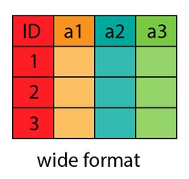

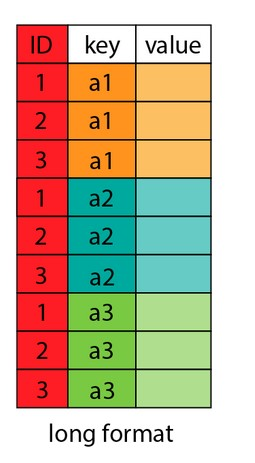

### a) `pivot_longer()`

Como ya se señaló, `pivot_longer()`nos permitirá pivotear los datos de manera tal que estos se transformen a un tabulado en formato **long**. Ello implica que el tabulado tendrá un mayor número de observaciones, reduciendo su cantidad de columnas.

En este caso, pivotearemos todas las columnas salvo `sector`, lo cual significa que tales columnas se subsumirán en una sola (en este caso, llamada “variable”), y sus respectivos valores en otra (en este caso, llamada “value”). Luego, la unidad de análisis pasará, de ser sujetos, a ser las variables. Para ello usamos el siguiente código:

```r
datos %>% #Creamos un nuevo objeto a partir de datos
  select(-ing_tot, -ends_with("_t")) %>%  #Des-seleccionamos la variable ing_tot, pues es de class numeric
  pivot_longer(cols=-c(1, id), #Pivoteamos a lo largo todas las columnas salvo la primera (sector)
               names_to = "variable", #Especificamos que la columna "variable" incluirá los nombres de cada una de las columnas pivoteadas
               values_to = "value") #Especificamos que la columna "value" incluirá los valores de cada una de las columnas pivoteadas
```

| sector | id | variable | value |
| --- | --- | --- | --- |
| Sector formal | 20256 | sexo | Mujer |
| Sector formal | 20256 | prevision | Si |
| Sector formal | 20256 | salud | Si |
| Sector formal | 20256 | contrato_dur | Indefinido |
| Sector formal | 24592 | sexo | Mujer |
| Sector formal | 24592 | prevision | Si |
| Sector formal | 24592 | salud | Si |
| Sector formal | 24592 | contrato_dur | Definido |
| Sector formal | 35136 | sexo | Mujer |
| Sector formal | 35136 | prevision | Si |

[output cut: 990 more lines]

```r
long <- datos %>%
  select(-ing_tot, -ends_with("_t")) %>%
  pivot_longer(cols=-c(1, id),
               names_to = "variable",
               values_to = "value")
```

Podemos darnos cuenta de que ahora nuestro set de datos sólo contiene 4 columnas, pero 75.940 filas. Podemos darnos cuenta que ahora, cada cuatro columnas, tenemos a un sujeto de la muestra.

### b) `pivot_wider`

Asimismo, las tablas largas (long) pueden ser transformadas a tablas anchas (wide) con la función `pivot_wider()`, lo cual implica que nuestra tabla reducirá su cantidad de filas y aumentará su número de columnas.

Para ello, sólo debemos especificar desde dónde extraeremos los nombres y los valores asociados a las nuevas columnas:

```r
wide <- long %>% #Creamos un nuevo objeto a partir de los datos de long
  pivot_wider(names_from = "variable", #Pivoteamos, tomando el nombre de las columnas desde la columna "variable"
              values_from = "value")
head(wide)
```

| sector | id | sexo | prevision | salud | contrato_dur |
| --- | --- | --- | --- | --- | --- |
| Sector formal | 20256 | Mujer | Si | Si | Indefinido |
| Sector formal | 24592 | Mujer | Si | Si | Definido |
| Sector formal | 35136 | Mujer | Si | Si | Indefinido |
| Hogares como empleadores | 235953 | Mujer | No | No | Indefinido |
| Sector formal | 251187 | Hombre | Si | Si | Indefinido |
| Sector formal | 318992 | Hombre | Si | Si | Indefinido |

## 7. `separate()`

La función `separate()` de `tidyr` nos permite convertir un character individual de una columna en múltiples columnas.

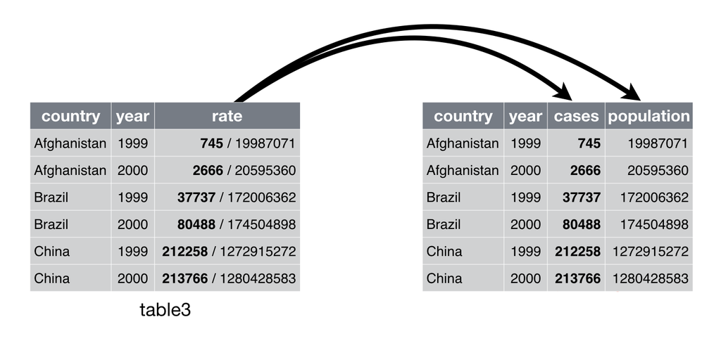

```r
separate <- datos %>% #Creamos un nuevo objeto desde datos
  mutate(sobre_prom = case_when(ing_tot <= mean(ing_tot) ~ "Bajo media",
                                ing_tot > mean(ing_tot) ~ "Sobre media")) %>% #Creamos una variable condicional con case_when(), para identificar quienes estan bajo y sobre la media de ingreso
  separate(sobre_prom, #Especificamos la columna que queremos separar
           into = c("sobre_o_bajo", "media")) #Especificamos en cuántas columnas queremos separar los characteres, y cómo se llamarán tales columnas
head(separate)
```

| sector | sexo | prevision | salud | contrato_dur | ss_t | svar_t | reg_t | id | ing_tot | sobre_o_bajo | media |
| --- | --- | --- | --- | --- | --- | --- | --- | --- | --- | --- | --- |
| Sector formal | Mujer | Si | Si | Indefinido | 320421.1 | 0 | 0 | 20256 | 320421.1 | Bajo | media |
| Sector formal | Mujer | Si | Si | Definido | 750000.0 | 0 | 0 | 24592 | 750000.0 | Bajo | media |
| Sector formal | Mujer | Si | Si | Indefinido | 900000.0 | 0 | 0 | 35136 | 900000.0 | Bajo | media |
| Hogares como empleadores | Mujer | No | No | Indefinido | 302041.6 | 0 | 0 | 235953 | 302041.6 | Bajo | media |
| Sector formal | Hombre | Si | Si | Indefinido | 900000.0 | 0 | 0 | 251187 | 900000.0 | Bajo | media |
| Sector formal | Hombre | Si | Si | Indefinido | 0.0 | 0 | 0 | 318992 | 0.0 | Bajo | media |

## 8. `unite()`

También podemos unir caracteres de columnas distintas, con la función `unite()` de `tidyr`.

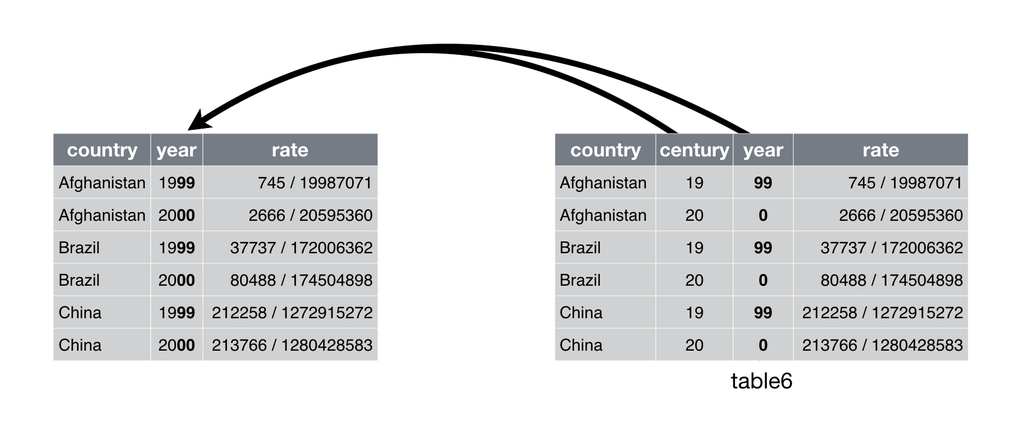

En este caso, volveremos a unir las columnas ¿Sobre o bajo? y Media en una sola, llamada sobre_prom. Por defecto, `unite()` une los caracteres con guiones bajos (_). Podemos especificar un nuevo separador con el argumento `sep`. En este caso, el separador será un espacio (" ")

```r
separate <- separate %>% #Modificamos el objeto separate
  unite(col = sobre_media, #Unimos en una nueva columna llamada sobre_media
        sobre_o_bajo:media, #Especificamos las columnas que deseamos unir
        sep = " ") #Especificamos el separador
head(separate)
```

| sector | sexo | prevision | salud | contrato_dur | ss_t | svar_t | reg_t | id | ing_tot | sobre_media |
| --- | --- | --- | --- | --- | --- | --- | --- | --- | --- | --- |
| Sector formal | Mujer | Si | Si | Indefinido | 320421.1 | 0 | 0 | 20256 | 320421.1 | Bajo media |
| Sector formal | Mujer | Si | Si | Definido | 750000.0 | 0 | 0 | 24592 | 750000.0 | Bajo media |
| Sector formal | Mujer | Si | Si | Indefinido | 900000.0 | 0 | 0 | 35136 | 900000.0 | Bajo media |
| Hogares como empleadores | Mujer | No | No | Indefinido | 302041.6 | 0 | 0 | 235953 | 302041.6 | Bajo media |
| Sector formal | Hombre | Si | Si | Indefinido | 900000.0 | 0 | 0 | 251187 | 900000.0 | Bajo media |
| Sector formal | Hombre | Si | Si | Indefinido | 0.0 | 0 | 0 | 318992 | 0.0 | Bajo media |

## 9. Unir datos

Otra de las herramientas fundamentales a la hora de trabajar con la estructura de los datos es unir dos tabulados distintos con los cuales estemos trabajando.

**Recomendaciones**

1. Conocer bien los datos x e y
2. Verifica las unidades de observación
3. Define tu variable “llave” o **key**
4. Define qué procedimiento quieres hacer
- ¿combinar, pegar filas, pegar columnas?

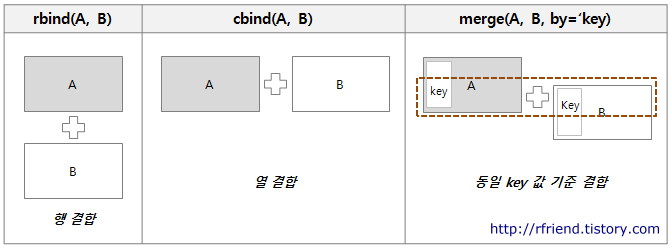

### a) `merge`

Una de las funciones más utilizadas para ello es `merge` del paquete `base` de R. Esta nos permite unir dos tabulados (data frames) que compartan una columna, y que tengan la misma cantidad de filas.

```r
esi2020_m <- readRDS(gzcon(url("https://github.com/learn-R/05-class/blob/main/input/data/ESI2020m.rds?raw=true"))) #Cargamos los datos que deseamos unir
merge(x = datos, #Unimos el dataframe datos
      y = esi2020_m, #con el dataframe esi2020_m
      by = c("sexo", "ing_tot")) #a partir de las columnas "sexo" e "ing_tot"
```

| sexo | ing_tot | sector | prevision | salud | contrato_dur | ss_t | svar_t | reg_t | id | efectivas |
| --- | --- | --- | --- | --- | --- | --- | --- | --- | --- | --- |
| Hombre | 0 | Sector formal | Si | Si | Indefinido | 0 | 0 | 0 | 346362449 | 21 |
| Hombre | 0 | Sector formal | Si | Si | Indefinido | 0 | 0 | 0 | 346362449 | 40 |
| Hombre | 0 | Sector formal | Si | Si | Indefinido | 0 | 0 | 0 | 346362449 | 0 |
| Hombre | 0 | Sector formal | Si | Si | Indefinido | 0 | 0 | 0 | 346362449 | 45 |
| Hombre | 0 | Sector formal | Si | Si | Indefinido | 0 | 0 | 0 | 346362449 | 45 |
| Hombre | 0 | Sector formal | Si | Si | Indefinido | 0 | 0 | 0 | 346362449 | 45 |
| Hombre | 0 | Sector formal | Si | Si | Indefinido | 0 | 0 | 0 | 346362449 | 48 |
| Hombre | 0 | Sector formal | Si | Si | Indefinido | 0 | 0 | 0 | 346362449 | 45 |
| Hombre | 0 | Sector formal | Si | Si | Indefinido | 0 | 0 | 0 | 346362449 | 56 |
| Hombre | 0 | Sector formal | Si | Si | Indefinido | 0 | 0 | 0 | 346362449 | 37 |

[output cut: 990 more lines]

```r
head(datos)
```

| sector | sexo | prevision | salud | contrato_dur | ss_t | svar_t | reg_t | id | ing_tot |
| --- | --- | --- | --- | --- | --- | --- | --- | --- | --- |
| Sector formal | Mujer | Si | Si | Indefinido | 320421.1 | 0 | 0 | 20256 | 320421.1 |
| Sector formal | Mujer | Si | Si | Definido | 750000.0 | 0 | 0 | 24592 | 750000.0 |
| Sector formal | Mujer | Si | Si | Indefinido | 900000.0 | 0 | 0 | 35136 | 900000.0 |
| Hogares como empleadores | Mujer | No | No | Indefinido | 302041.6 | 0 | 0 | 235953 | 302041.6 |
| Sector formal | Hombre | Si | Si | Indefinido | 900000.0 | 0 | 0 | 251187 | 900000.0 |
| Sector formal | Hombre | Si | Si | Indefinido | 0.0 | 0 | 0 | 318992 | 0.0 |

[figure not shown]

### b) `bind_cols()`

Otra cosa que podemos hacer es, simplemente, pegar una columna de un dataframe a otro. Para ello recurrimos a la función `bind_cols()` de `dplyr`:

```r
a <- select(datos, 1:5) # Seleccionamos las primeras cinco columnas de datos
b <- select(datos, 3:7) # Seleccionamos las últimas cinco columnas de datos
col_un <- bind_cols(a, b) #Unimos ambos dataframes a partir de sus columnas
```

```
* prevision -> prevision...3
* salud -> salud...4
* contrato_dur -> contrato_dur...5
* prevision -> prevision...6
* salud -> salud...7
* ...
```

```r
head(col_un)
```

| sector | sexo | prevision...3 | salud...4 | contrato_dur...5 | prevision...6 | salud...7 | contrato_dur...8 | ss_t | svar_t |
| --- | --- | --- | --- | --- | --- | --- | --- | --- | --- |
| Sector formal | Mujer | Si | Si | Indefinido | Si | Si | Indefinido | 320421.1 | 0 |
| Sector formal | Mujer | Si | Si | Definido | Si | Si | Definido | 750000.0 | 0 |
| Sector formal | Mujer | Si | Si | Indefinido | Si | Si | Indefinido | 900000.0 | 0 |
| Hogares como empleadores | Mujer | No | No | Indefinido | No | No | Indefinido | 302041.6 | 0 |
| Sector formal | Hombre | Si | Si | Indefinido | Si | Si | Indefinido | 900000.0 | 0 |
| Sector formal | Hombre | Si | Si | Indefinido | Si | Si | Indefinido | 0.0 | 0 |

Vemos que simplemente pegó `a` y `b`. Eso implica que tenemos columnas repetidas. Cuando estemos seguras/os de que hay columnas repetidas entre dos dataframes que queramos unir, emplearemos `merge()` mientras que, si estos no comparten ninguna columna, recurrimos a `bing_cols()`

### c) `bind_rows()`

También podemos unir dos dataframes a partir de sus filas, con la función `bind_rows()` de `dplyr`

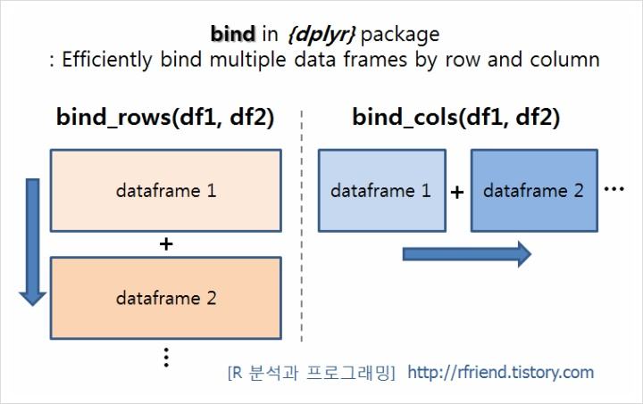

```r
a <- a[1:10000,] # Seleccionamos las primeras 10.000 filas de a
b <- b[10001:18985,] # Seleccionamos las últimas 8.985 filas de b
row_un <- bind_rows(a, b)
head(row_un)
```

| sector | sexo | prevision | salud | contrato_dur | ss_t | svar_t |
| --- | --- | --- | --- | --- | --- | --- |
| Sector formal | Mujer | Si | Si | Indefinido | NA | NA |
| Sector formal | Mujer | Si | Si | Definido | NA | NA |
| Sector formal | Mujer | Si | Si | Indefinido | NA | NA |
| Hogares como empleadores | Mujer | No | No | Indefinido | NA | NA |
| Sector formal | Hombre | Si | Si | Indefinido | NA | NA |
| Sector formal | Hombre | Si | Si | Indefinido | NA | NA |

`bind_rows()` nos permite pegar filas, independientemente si ambos dataframes comparten las mismas columnas. En caso de que ambos dataframes no compartan alguna columna, esta función rellenará con valores nulos (`NA`)

# Resumen

En este práctico aprendimos a

1. Agrupar datos por filas y columnas.
2. Manipular datos (tidydata), transformando la estructura de estos a una ancha o larga.
3. Separar y unir caracteres de una columna.
4. Unir datos, a partir de filas y columnas.

# Reporte de progreso

¡No olviden llenar el [reporte de progreso](https://learn-r.formr.org)! En tu correo electrónico está disponible el código mediante al cuál debes acceder para actualizar tu estado de avance del curso.